# Marketing Data Analysis

Hanie Jalili

2022-11-10

## Introduction

The data is related to a chain company. The purpose of collecting this data is to check the impact of this company’s advertising campaigns on its customers.

In this data, we have 26 variables that are related to the demographic information of customers, customer behavior, the effectiveness of advertisements, and the amount of purchase of various products by customers.

## Exploring and cleaning the data set

### Exploring

First, we start by loading the data into R Studio to view it.

```r
data<-read.table("E:\\Users\\ASUS\\Documents\\term7\\multivariate analysis\\mydata.csv",header = T,sep = ",")
attach(data)
dim(data)
```

```
## [1] 2240   26
```

```r
colnames(data)
```

```
##  [1] "Birth"          "Education"      "Marital_Status" "Income"
##  [5] "Kid"            "Teen"           "Dt_Customer"    "Recency"
##  [9] "Complain"       "Wines"          "Fruits"         "Meat"
## [13] "Fish"           "Sweet"          "Gold"           "Deals"
## [17] "Web"            "Catalog"        "Store"          "WebVisitsMonth"
## [21] "AcceptedCmp3"   "AcceptedCmp4"   "AcceptedCmp5"   "AcceptedCmp1"
## [25] "AcceptedCmp2"   "Response"
```

We have 2240 observations and 26 variables. Now we summarize the dataset.

```r
library(skimr)
skim(data)
```

Data summary

| Name | data |
| --- | --- |
| Number of rows | 2240 |
| Number of columns | 26 |
| _______________________ |  |
| Column type frequency: |  |
| character | 3 |
| numeric | 23 |
| ________________________ |  |
| Group variables | None |

**Variable type: character**

| skim_variable | n_missing | complete_rate | min | max | empty | n_unique | whitespace |
| --- | --- | --- | --- | --- | --- | --- | --- |
| Education | 0 | 1 | 3 | 10 | 0 | 5 | 0 |
| Marital_Status | 0 | 1 | 4 | 8 | 0 | 8 | 0 |
| Dt_Customer | 0 | 1 | 8 | 8 | 0 | 663 | 0 |

**Variable type: numeric**

| skim_variable | n_missing | complete_rate | mean | sd | p0 | p25 | p50 | p75 | p100 | hist |
| --- | --- | --- | --- | --- | --- | --- | --- | --- | --- | --- |
| Birth | 0 | 1.00 | 1968.91 | 11.70 | 1940 | 1959.00 | 1970.0 | 1977.00 | 1996 | ▂▆▇▇▂ |
| Income | 24 | 0.99 | 52247.25 | 25173.08 | 1730 | 35303.00 | 51381.5 | 68522.00 | 666666 | ▇▁▁▁▁ |
| Kid | 0 | 1.00 | 0.44 | 0.54 | 0 | 0.00 | 0.0 | 1.00 | 2 | ▇▁▆▁▁ |
| Teen | 0 | 1.00 | 0.51 | 0.54 | 0 | 0.00 | 0.0 | 1.00 | 2 | ▇▁▇▁▁ |
| Recency | 0 | 1.00 | 49.11 | 28.96 | 0 | 24.00 | 49.0 | 74.00 | 99 | ▇▇▇▇▇ |
| Complain | 0 | 1.00 | 0.01 | 0.10 | 0 | 0.00 | 0.0 | 0.00 | 1 | ▇▁▁▁▁ |
| Wines | 0 | 1.00 | 303.94 | 336.60 | 0 | 23.75 | 173.5 | 504.25 | 1493 | ▇▂▂▁▁ |
| Fruits | 0 | 1.00 | 26.30 | 39.77 | 0 | 1.00 | 8.0 | 33.00 | 199 | ▇▁▁▁▁ |
| Meat | 0 | 1.00 | 166.95 | 225.72 | 0 | 16.00 | 67.0 | 232.00 | 1725 | ▇▁▁▁▁ |
| Fish | 0 | 1.00 | 37.53 | 54.63 | 0 | 3.00 | 12.0 | 50.00 | 259 | ▇▁▁▁▁ |
| Sweet | 0 | 1.00 | 27.06 | 41.28 | 0 | 1.00 | 8.0 | 33.00 | 263 | ▇▁▁▁▁ |
| Gold | 0 | 1.00 | 44.02 | 52.17 | 0 | 9.00 | 24.0 | 56.00 | 362 | ▇▁▁▁▁ |
| Deals | 0 | 1.00 | 2.33 | 1.93 | 0 | 1.00 | 2.0 | 3.00 | 15 | ▇▂▁▁▁ |
| Web | 0 | 1.00 | 4.08 | 2.78 | 0 | 2.00 | 4.0 | 6.00 | 27 | ▇▃▁▁▁ |
| Catalog | 0 | 1.00 | 2.66 | 2.92 | 0 | 0.00 | 2.0 | 4.00 | 28 | ▇▂▁▁▁ |
| Store | 0 | 1.00 | 5.79 | 3.25 | 0 | 3.00 | 5.0 | 8.00 | 13 | ▂▇▂▃▂ |
| WebVisitsMonth | 0 | 1.00 | 5.32 | 2.43 | 0 | 3.00 | 6.0 | 7.00 | 20 | ▅▇▁▁▁ |
| AcceptedCmp3 | 0 | 1.00 | 0.07 | 0.26 | 0 | 0.00 | 0.0 | 0.00 | 1 | ▇▁▁▁▁ |
| AcceptedCmp4 | 0 | 1.00 | 0.07 | 0.26 | 0 | 0.00 | 0.0 | 0.00 | 1 | ▇▁▁▁▁ |
| AcceptedCmp5 | 0 | 1.00 | 0.07 | 0.26 | 0 | 0.00 | 0.0 | 0.00 | 1 | ▇▁▁▁▁ |
| AcceptedCmp1 | 0 | 1.00 | 0.06 | 0.25 | 0 | 0.00 | 0.0 | 0.00 | 1 | ▇▁▁▁▁ |
| AcceptedCmp2 | 0 | 1.00 | 0.01 | 0.11 | 0 | 0.00 | 0.0 | 0.00 | 1 | ▇▁▁▁▁ |
| Response | 0 | 1.00 | 0.15 | 0.36 | 0 | 0.00 | 0.0 | 0.00 | 1 | ▇▁▁▁▂ |

### Cleaning the dataset

For data analysis, it is necessary to change the data type to numerical and factorial type.

```r
Birth <- as.numeric((Birth))
Income <- as.numeric((Income))
Recency <- as.numeric((Recency))
Wines <- as.numeric((Wines))
Fruits <- as.numeric((Fruits))
Meat <- as.numeric((Meat))
Fish <- as.numeric((Fish))
Sweet <- as.numeric((Sweet))
Gold <- as.numeric((Gold))
Deals <- as.numeric((Deals))
Web <- as.numeric((Web))
Catalog <- as.numeric((Catalog))
Store <- as.numeric((Store))
WebVisitsMonth <- as.numeric((WebVisitsMonth))

Education <- as.factor((Education))
Marital_Status <- as.factor((Marital_Status))
Kid <- as.factor((Kid))
Teen <- as.factor((Teen))
Complain <- as.factor((Complain))
AcceptedCmp3 <- as.factor((AcceptedCmp3))
AcceptedCmp4 <- as.factor((AcceptedCmp4))
AcceptedCmp5 <- as.factor((AcceptedCmp5))
AcceptedCmp1 <- as.factor((AcceptedCmp1))
AcceptedCmp2 <- as.factor((AcceptedCmp2))
Response <- as.factor((Response))
```

In the previous investigations, we saw that only the “income” variable has missing values. To find the best replacement value for the missing values, we first pay attention to the distribution of the “income” variable:

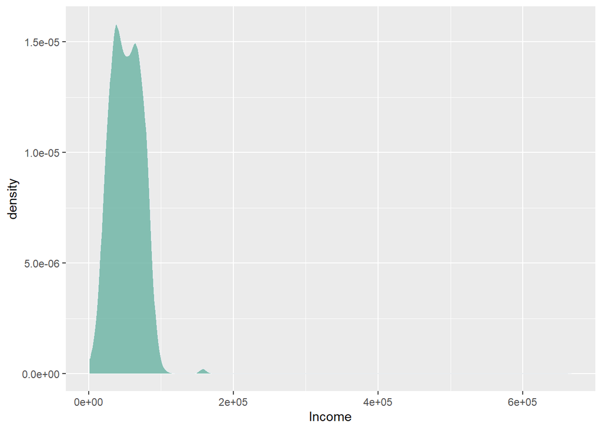

```r
library(ggplot2)
  ggplot(data, aes(x=Income)) +
  geom_density(fill="#69b3a2", color="#e9ecef", alpha=0.8)
```

```r
shapiro.test(Income)
```

```
##
##  Shapiro-Wilk normality test
##
## data:  Income
## W = 0.77705, p-value < 2.2e-16
```

The assumption of normality of income distribution was rejected and we also see that its distribution is not symmetrical. So it is better to replace the missing values with the median of the income variable.

```r
sum(is.na(Income))
```

```
## [1] 24
```

```r
m = median(Income,na.rm = TRUE)
sel = is.na(Income)
Income[sel] = m
```

To check outliers in quantitative data, we divide them into the following three categories:

- The number of purchases made in different ways
- Consumption of different products in the last two years
- Income

```r
num_purchases=data.frame(Deals,Web,Catalog,Store,WebVisitsMonth)
income=data.frame(Income)
mnt_products=data.frame(Wines,Fruits,Meat,Fish,Sweet,Gold)
summary(num_purchases)
```

```
##      Deals             Web            Catalog           Store
##  Min.   : 0.000   Min.   : 0.000   Min.   : 0.000   Min.   : 0.00
##  1st Qu.: 1.000   1st Qu.: 2.000   1st Qu.: 0.000   1st Qu.: 3.00
##  Median : 2.000   Median : 4.000   Median : 2.000   Median : 5.00
##  Mean   : 2.325   Mean   : 4.085   Mean   : 2.662   Mean   : 5.79
##  3rd Qu.: 3.000   3rd Qu.: 6.000   3rd Qu.: 4.000   3rd Qu.: 8.00
##  Max.   :15.000   Max.   :27.000   Max.   :28.000   Max.   :13.00
##  WebVisitsMonth
##  Min.   : 0.000
##  1st Qu.: 3.000
##  Median : 6.000
##  Mean   : 5.317
##  3rd Qu.: 7.000
##  Max.   :20.000
```

```r
summary(Income)
```

```
##    Min. 1st Qu.  Median    Mean 3rd Qu.    Max.
##    1730   35539   51382   52238   68290  666666
```

```r
summary(mnt_products)
```

```
##      Wines             Fruits           Meat             Fish
##  Min.   :   0.00   Min.   :  0.0   Min.   :   0.0   Min.   :  0.00
##  1st Qu.:  23.75   1st Qu.:  1.0   1st Qu.:  16.0   1st Qu.:  3.00
##  Median : 173.50   Median :  8.0   Median :  67.0   Median : 12.00
##  Mean   : 303.94   Mean   : 26.3   Mean   : 166.9   Mean   : 37.53
##  3rd Qu.: 504.25   3rd Qu.: 33.0   3rd Qu.: 232.0   3rd Qu.: 50.00
##  Max.   :1493.00   Max.   :199.0   Max.   :1725.0   Max.   :259.00
##      Sweet             Gold
##  Min.   :  0.00   Min.   :  0.00
##  1st Qu.:  1.00   1st Qu.:  9.00
##  Median :  8.00   Median : 24.00
##  Mean   : 27.06   Mean   : 44.02
##  3rd Qu.: 33.00   3rd Qu.: 56.00
##  Max.   :263.00   Max.   :362.00
```

Now, to see the outlier values more clearly, we draw their graphs:

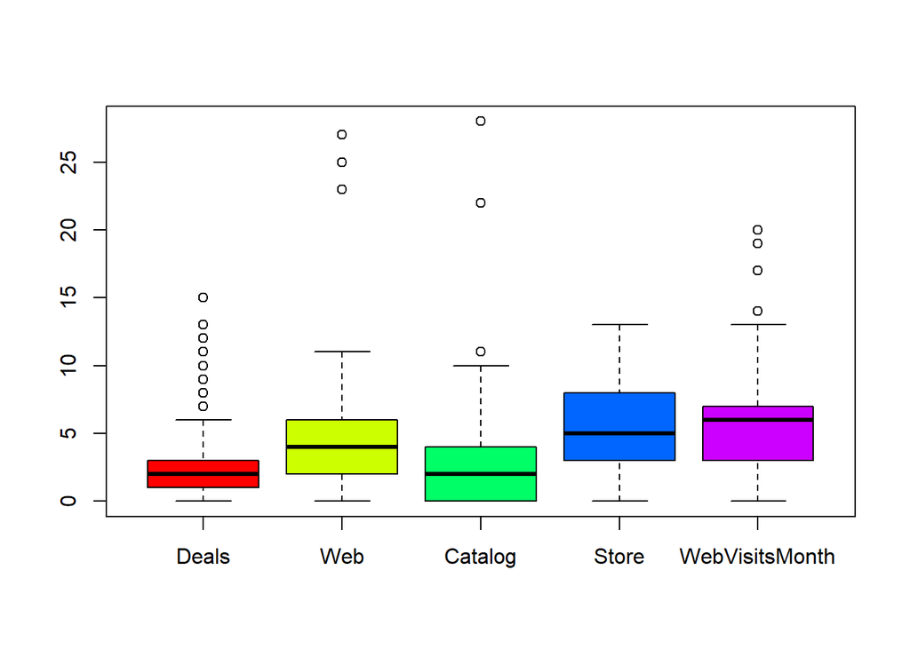

```r
boxplot(num_purchases, col = rainbow(ncol(num_purchases)))
```

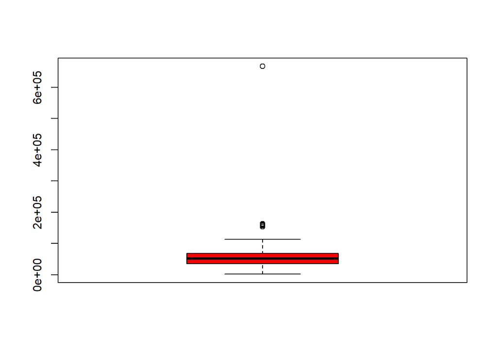

```r
boxplot(income, col = rainbow(ncol(income)))
```

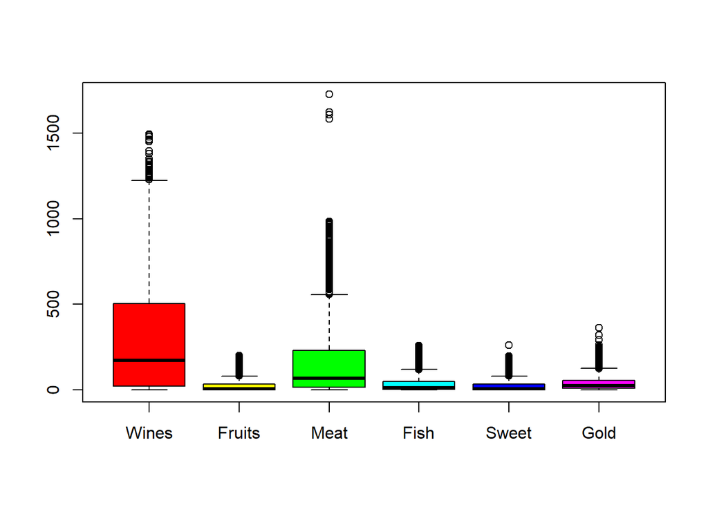

```r
boxplot(mnt_products, col = rainbow(ncol(mnt_products)))
```

```r
new_data<- filter(data,Income <= 200000)
new_data=as.data.frame(new_data)
```

## Analysis & results

Our goal of analyzing this data is to investigate the effect of different levels of the advertising campaign on other variables.

### The effect of campaigns on consumption of products

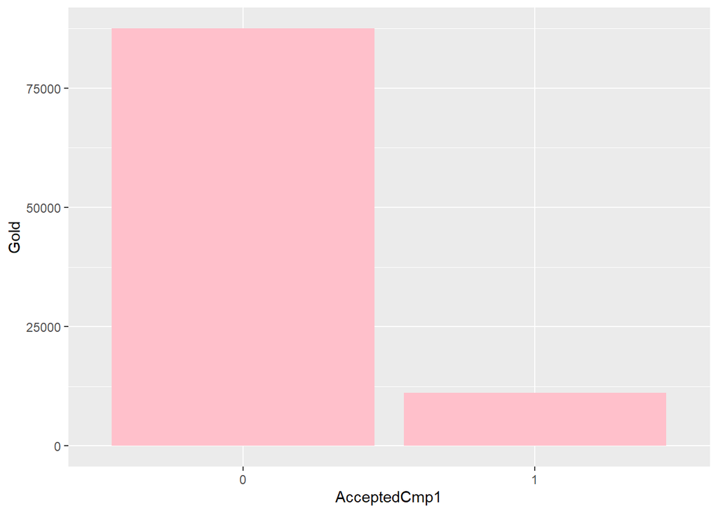

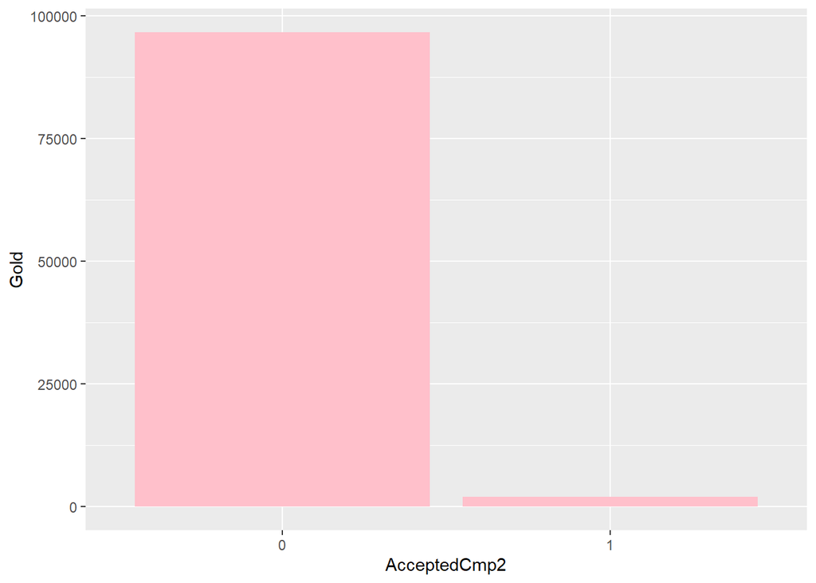

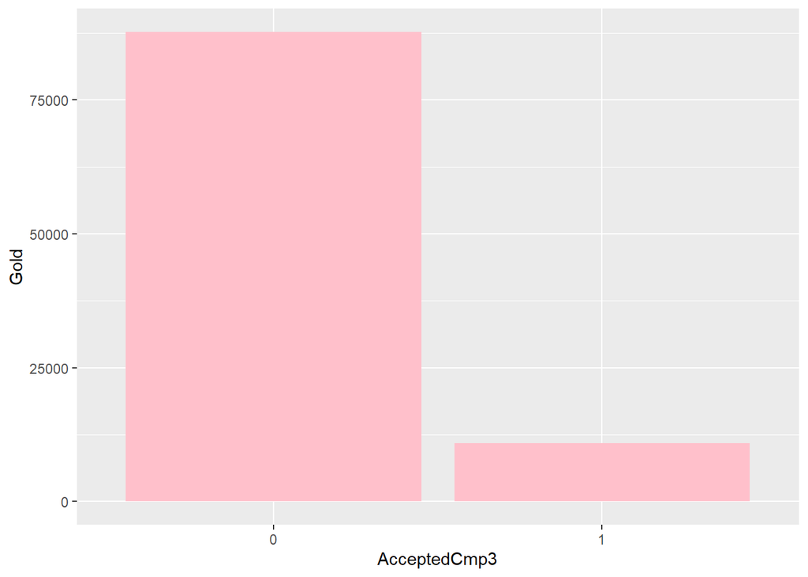

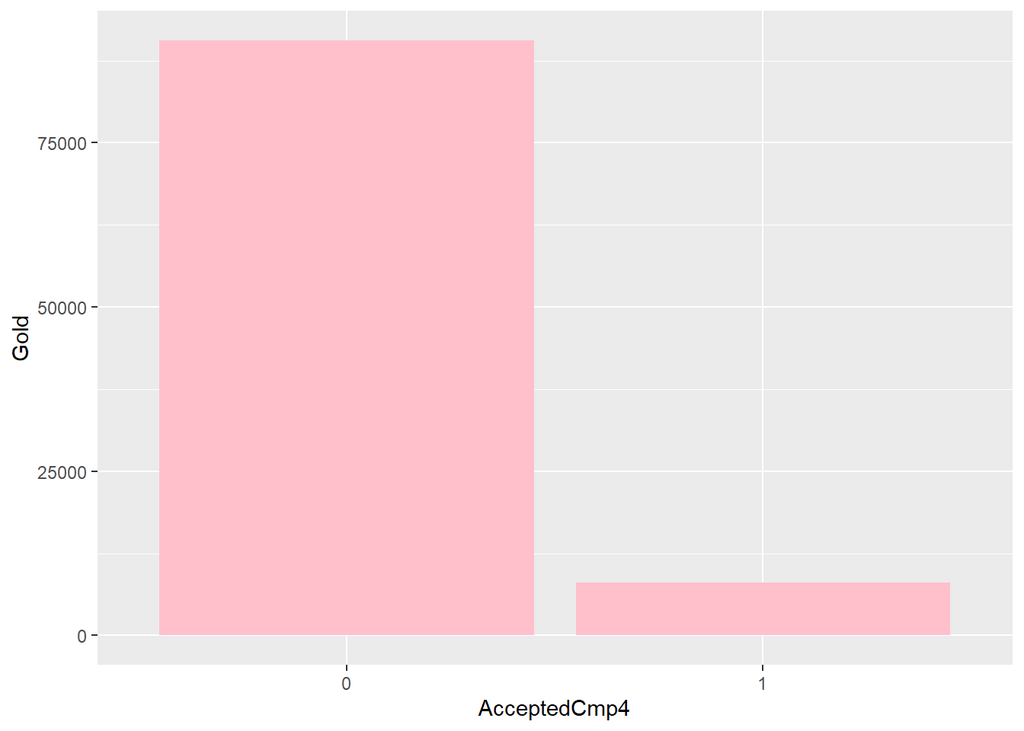

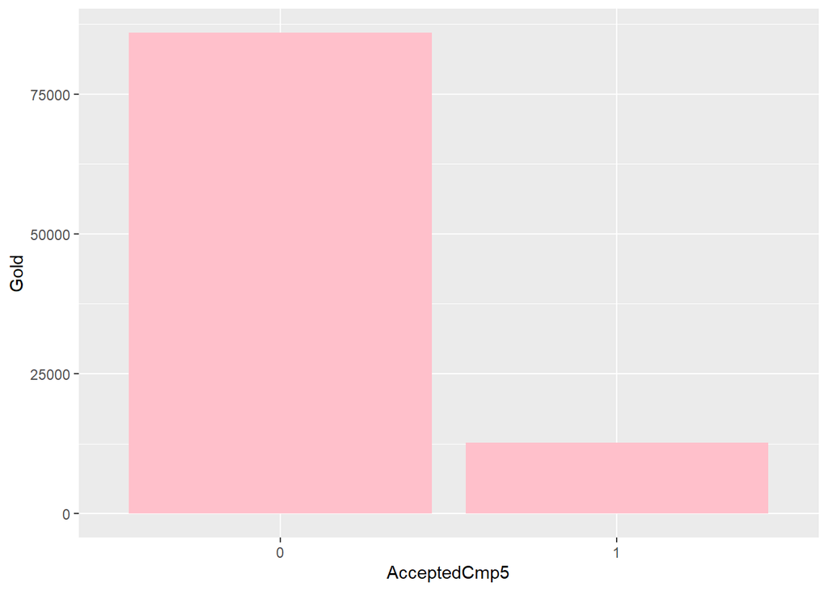

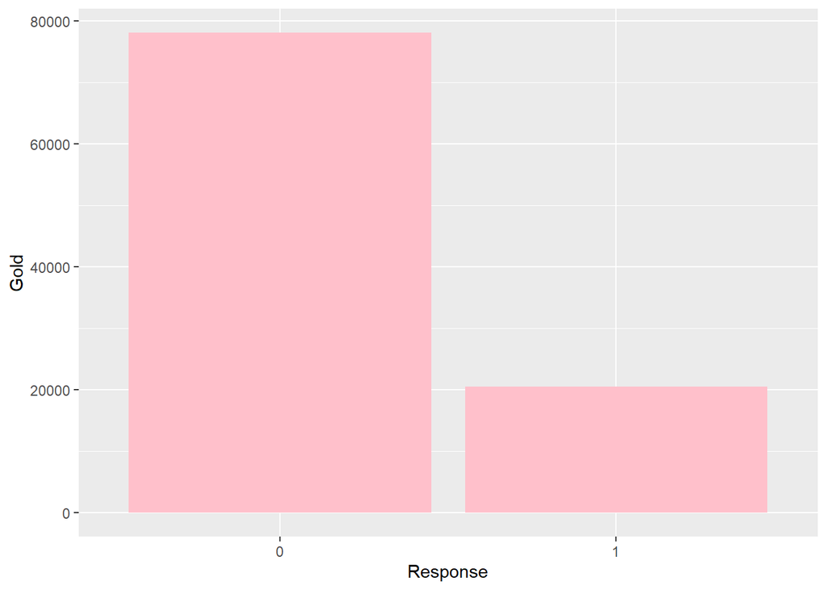

```r
library(ggplot2)
ggplot(data=new_data, aes(x=AcceptedCmp1, y=Gold)) +
  geom_bar(stat="identity", fill="pink")
ggplot(new_data, aes(x=AcceptedCmp2, y=Gold)) +
  geom_bar(stat = "identity", fill="pink")
ggplot(new_data, aes(x=AcceptedCmp3, y=Gold)) +
  geom_bar(stat = "identity", fill="pink")
ggplot(new_data, aes(x=AcceptedCmp4, y=Gold)) +
  geom_bar(stat = "identity", fill="pink")
ggplot(new_data, aes(x=AcceptedCmp5, y=Gold)) +
  geom_bar(stat = "identity", fill="pink")
ggplot(new_data, aes(x=Response, y=Gold)) +
  geom_bar(stat = "identity", fill="pink")
```

The last advertising campaign had the greatest impact on gold purchases in the last two years, and the second campaign had the least impact on gold purchases.

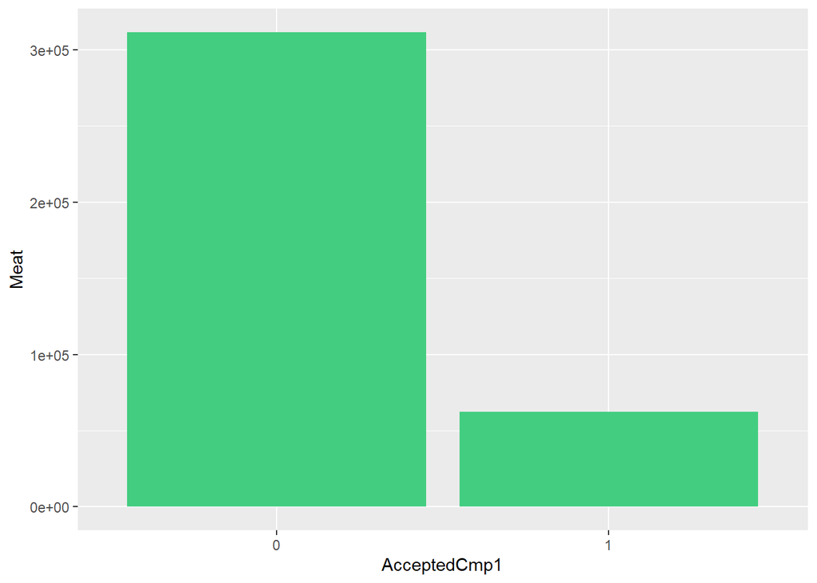

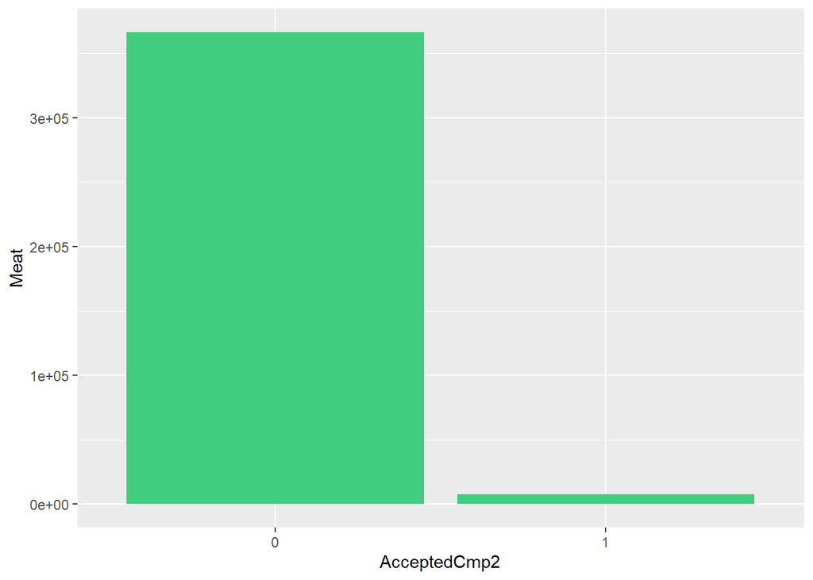

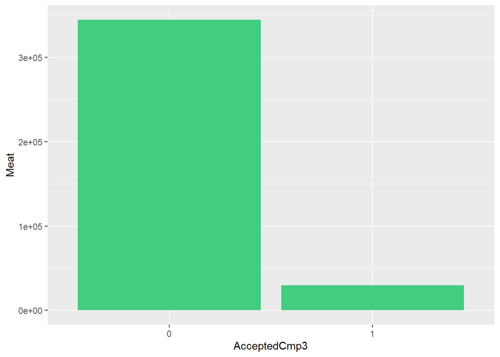

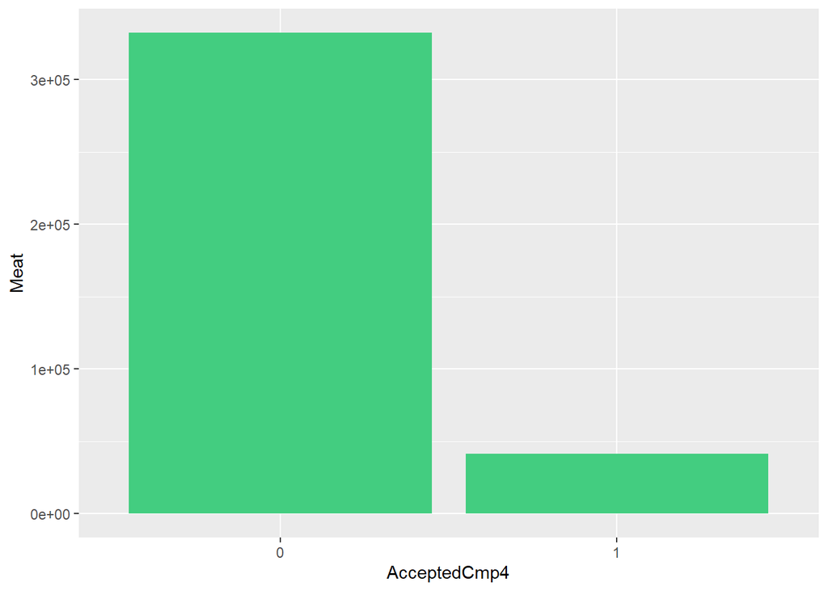

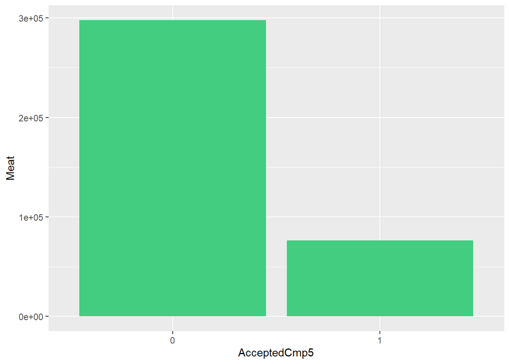

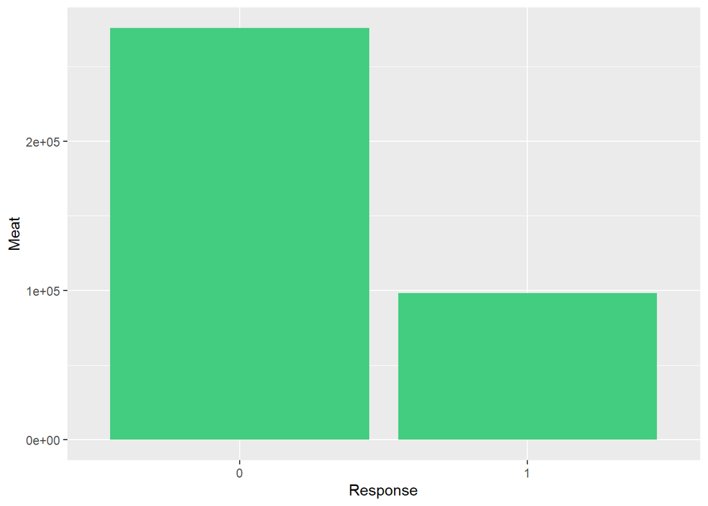

```r
library(ggplot2)
ggplot(new_data, aes(x=AcceptedCmp1, y=Meat)) +
  geom_bar(stat = "identity", fill="seagreen3")
ggplot(new_data, aes(x=AcceptedCmp2, y=Meat)) +
  geom_bar(stat = "identity", fill="seagreen3")
ggplot(new_data, aes(x=AcceptedCmp3, y=Meat)) +
  geom_bar(stat = "identity", fill="seagreen3")
ggplot(new_data, aes(x=AcceptedCmp4, y=Meat)) +
  geom_bar(stat = "identity", fill="seagreen3")
ggplot(new_data, aes(x=AcceptedCmp5, y=Meat)) +
  geom_bar(stat = "identity", fill="seagreen3")
ggplot(new_data, aes(x=Response, y=Meat)) +
  geom_bar(stat = "identity", fill="seagreen3")
```

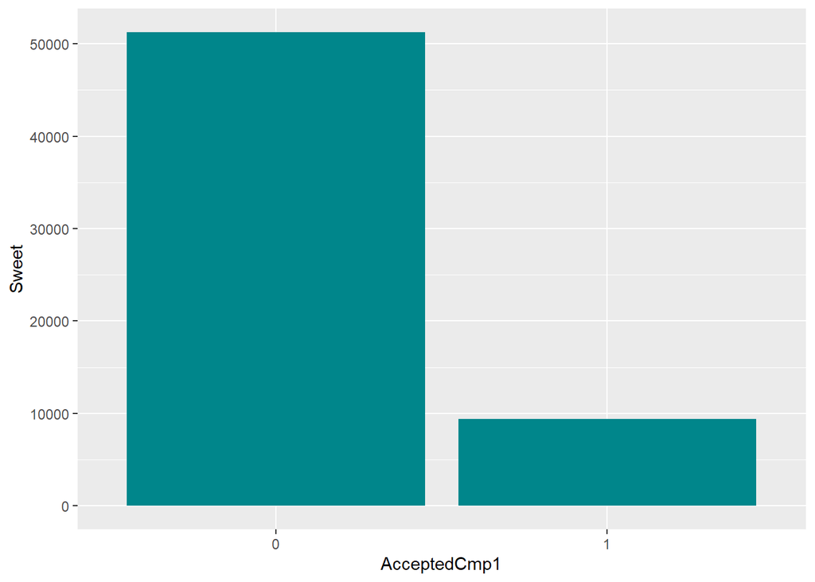

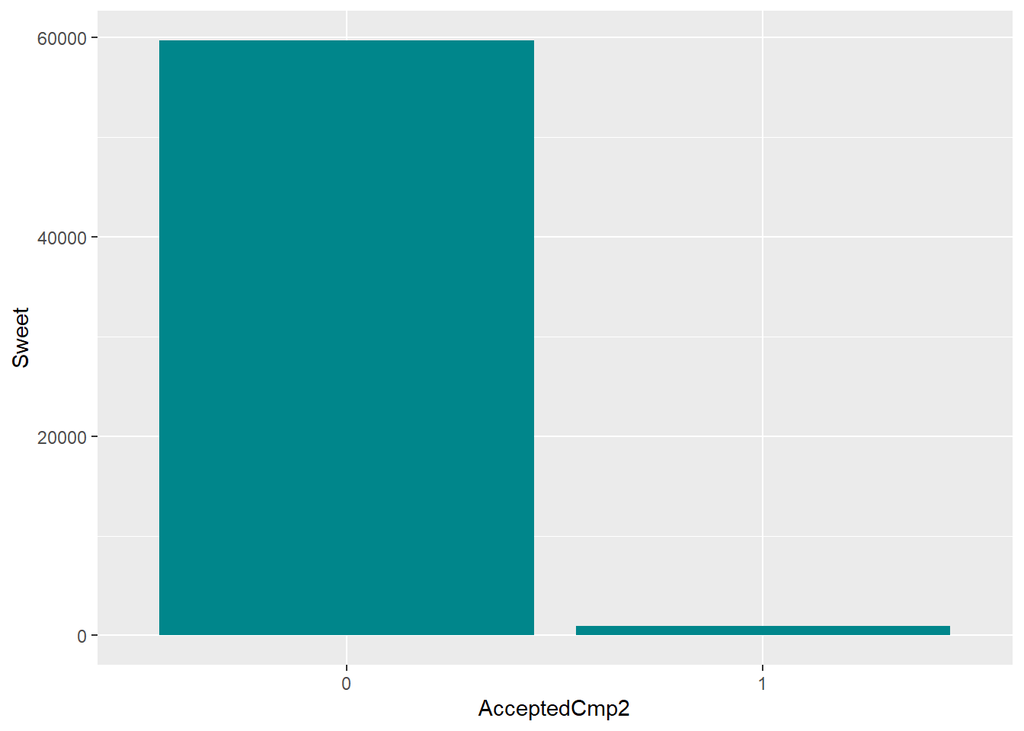

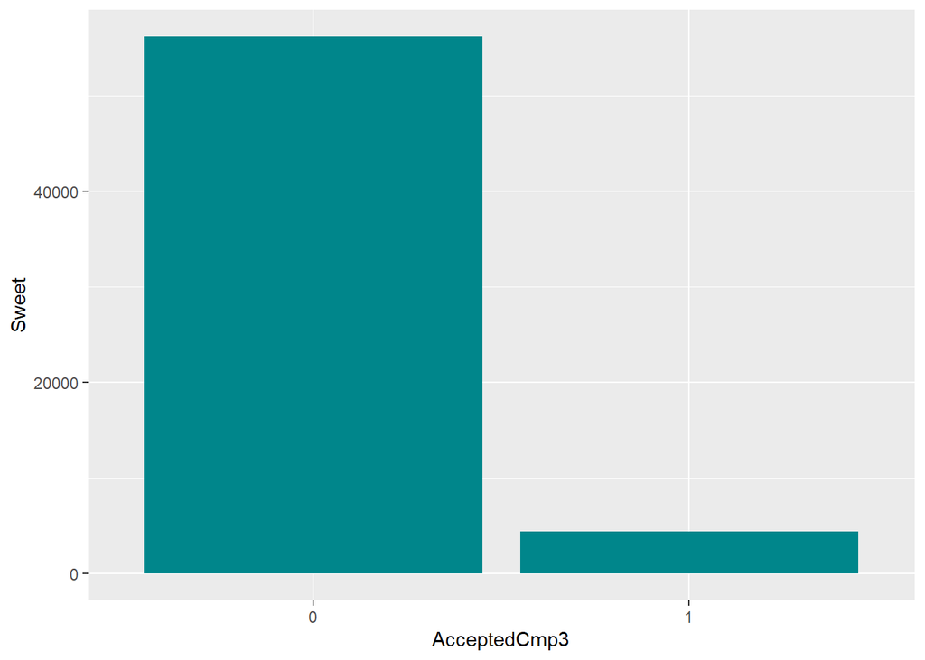

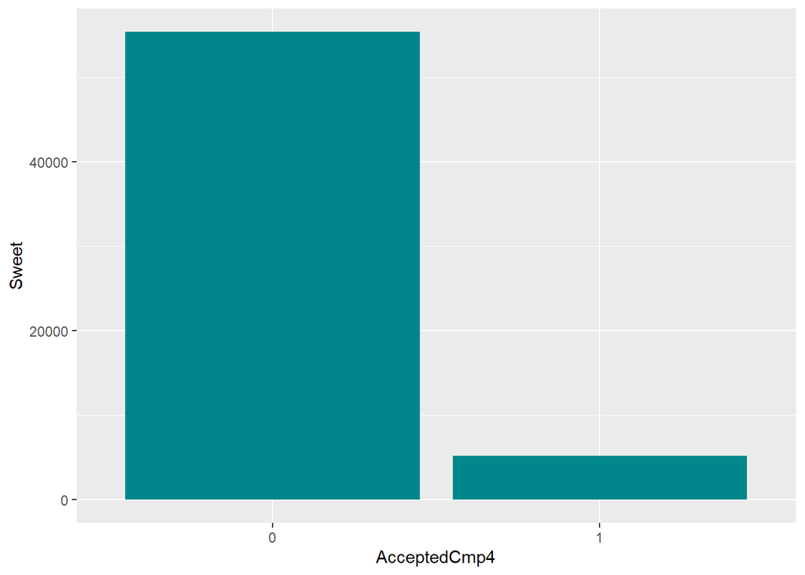

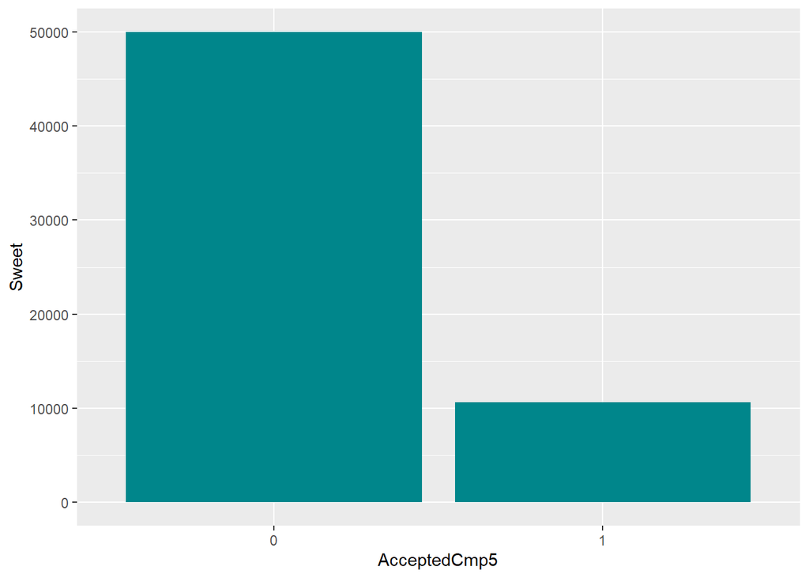

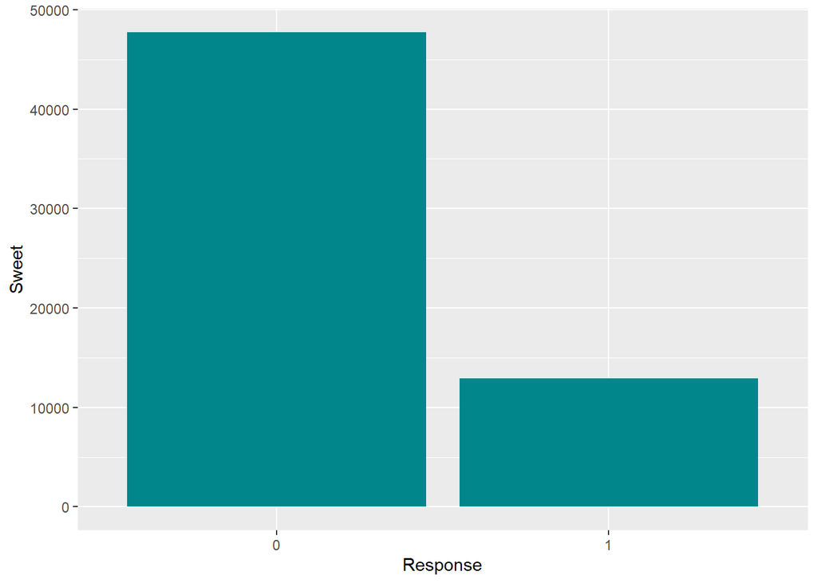

```r
library(ggplot2)
ggplot(new_data, aes(x=AcceptedCmp1, y=Sweet)) +
  geom_bar(stat = "identity", fill="turquoise4")
ggplot(new_data, aes(x=AcceptedCmp2, y=Sweet)) +
  geom_bar(stat = "identity", fill="turquoise4")
ggplot(new_data, aes(x=AcceptedCmp3, y=Sweet)) +
  geom_bar(stat = "identity", fill="turquoise4")
ggplot(new_data, aes(x=AcceptedCmp4, y=Sweet)) +
  geom_bar(stat = "identity", fill="turquoise4")
ggplot(new_data, aes(x=AcceptedCmp5, y=Sweet)) +
  geom_bar(stat = "identity", fill="turquoise4")
ggplot(new_data, aes(x=Response, y=Sweet)) +
  geom_bar(stat = "identity", fill="turquoise4")
```

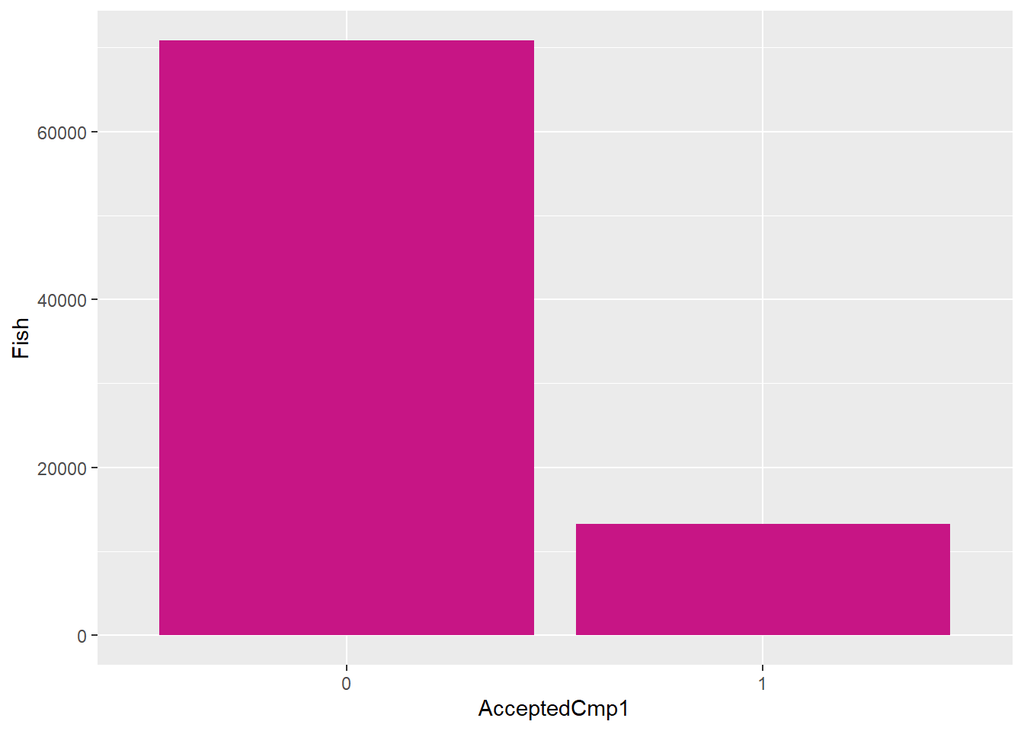

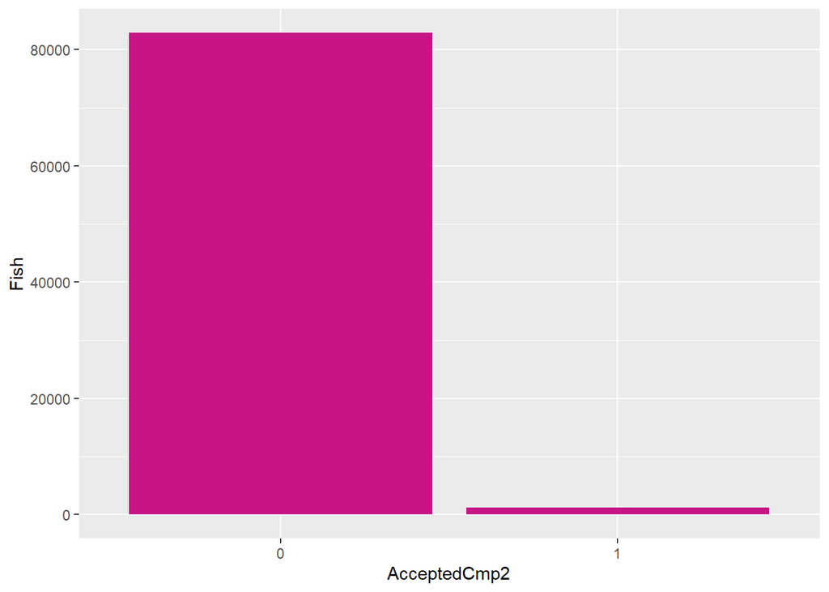

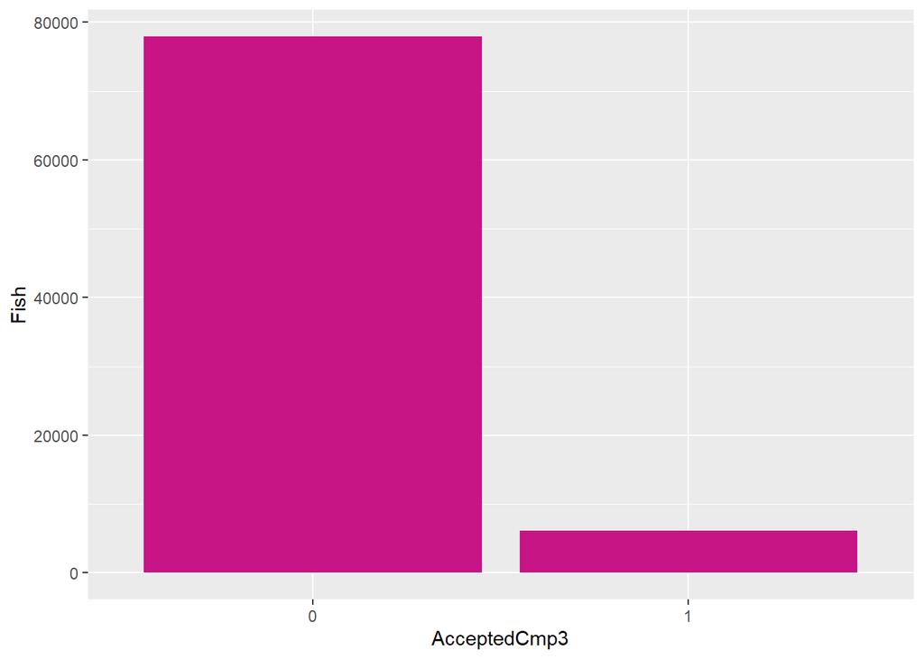

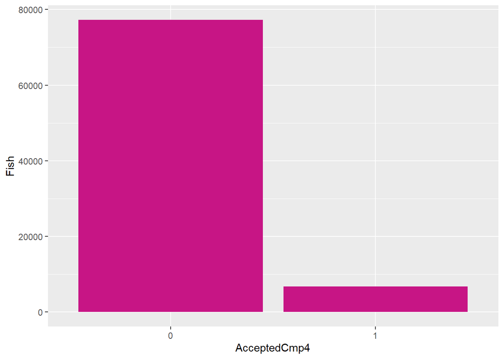

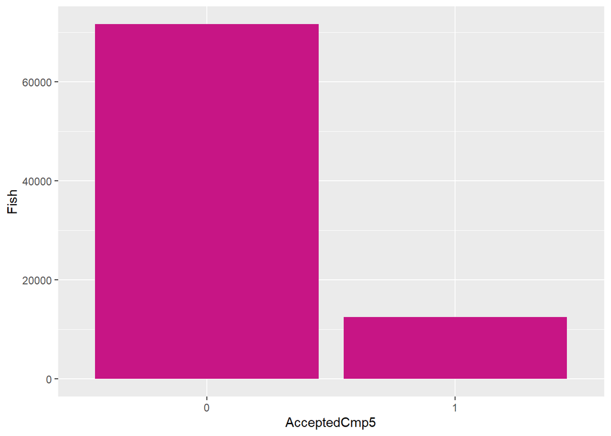

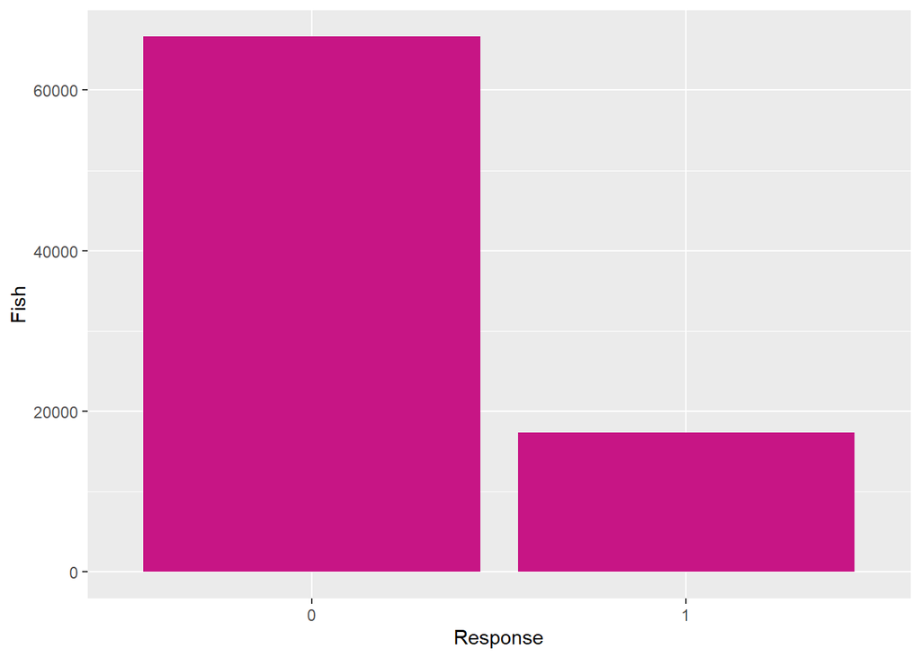

```r
library(ggplot2)
ggplot(new_data, aes(x=AcceptedCmp1, y=Fish)) +
  geom_bar(stat = "identity", fill="mediumvioletred")
ggplot(new_data, aes(x=AcceptedCmp2, y=Fish)) +
  geom_bar(stat = "identity", fill="mediumvioletred")
ggplot(new_data, aes(x=AcceptedCmp3, y=Fish)) +
  geom_bar(stat = "identity", fill="mediumvioletred")
ggplot(new_data, aes(x=AcceptedCmp4, y=Fish)) +
  geom_bar(stat = "identity", fill="mediumvioletred")
ggplot(new_data, aes(x=AcceptedCmp5, y=Fish)) +
  geom_bar(stat = "identity", fill="mediumvioletred")
ggplot(new_data, aes(x=Response, y=Fish)) +
  geom_bar(stat = "identity", fill="mediumvioletred")
```